# Credit Risk Analytics II (Hazard Rates)

**Dr Richard Diamond & Kannan Singaravelu**

# Credit Curve

The table below shows the term structure of credit spreads (in bps) for two reference entities: Wells Fargo (WFC) - a well-rated institution and Clear Channel Communication (CCMO) - a highly leveraged entity with oncoming problems with refinancing in 2011, which were known to the markets.

Make your own observation about CCMO spreads. While you would prefer to buy cheaper 1Y CDS, that might not be available, or allowed.

| Maturity | WFC | CCMO | Z(0;T) |
| --- | --- | --- | --- |
| 1Y | 50 | 751 | 0.97 |
| 2Y | 77 | 1164 | 0.94 |
| 3Y | 94 | 1874 | 0.92 |
| 5Y | 125 | 4156 | 0.86 |
| 7Y | 133 | 6083 | 0.81 |

The objective here is to bootstrap implied survival probabilities along with the term structure of hazard rate for

- WFC bank with recovery rate of 50%
- CCMO corporation with recovery rate of 10%

Extending CDS Analytics - I, we will study an effect of increase in recovery rate on implied survival probabilities. We also will explore what happens with hazard rates and offer the intuition (or counter-intuition) behind the Credit Triangle.

```python
# Import libraries
import pandas as pd
import numpy as np
from numpy import *

# Plotting library
import matplotlib
import matplotlib.pyplot as plt

# Plot settings
matplotlib.rcParams['figure.figsize'] = [14.0, 8.0]
matplotlib.rcParams['font.size'] = 18
matplotlib.rcParams['lines.linewidth'] = 2.0

# Interactive plotting
## import cufflinks as cf
## cf.set_config_file(offline=True)

#cf.set_config_file(theme = 'pearl')
# cf.getThemes() ['ggplot', 'pearl', 'solar', 'space', 'white', 'polar', 'henanigans']
```

```python
# subsume list of inputs into a dataframe
cds = pd.DataFrame({'Maturity': [1, 2, 3, 5, 7],
                   'WFC': [50, 77, 94, 125, 133],
                   'CCMO': [751, 1164, 1874, 4156, 6083],
                   'Df': [0.97, 0.94, 0.92, 0.86, 0.81]})
# output
cds
```

|  | Maturity | WFC | CCMO | Df |
| --- | --- | --- | --- | --- |
| 0 | 1 | 50 | 751 | 0.97 |
| 1 | 2 | 77 | 1164 | 0.94 |
| 2 | 3 | 94 | 1874 | 0.92 |
| 3 | 5 | 125 | 4156 | 0.86 |
| 4 | 7 | 133 | 6083 | 0.81 |

## Interpolation

Given the missing data points in the CDS table, we'll have to perform interpolation to derive the missing tenor and spreads before we proceed with our analysis.

### Discount Factors

For discounting factors, we'll do a log-linear interpolation for $ \tau_i < \tau < \tau_{i+1} $,

$$ lnDF(0,\tau) = \frac {\tau - \tau_i}{\tau_{i+1} - \tau_i} \space lnDF(0, \tau_{i+1}) + \frac {\tau_{i+1} - \tau}{\tau_{i+1} - \tau_i} \space lnDF(0, \tau_i) $$

We'll now create a User Defined Function (UDF) in Python to derive the discount factors.

```python
def get_discount_factor(maturity, discountfactor, tenor):

    max_time_index = len(maturity) - 1

    if tenor == 0: Df = 1.
    if tenor > 0 and tenor < maturity[0]: Df = discountfactor[0]
    if tenor >= maturity[max_time_index]: Df = discountfactor[max_time_index]

    for i in range(0, max_time_index):
         if tenor >= maturity[i] and tenor < maturity[i+1]:
            term1 = ((tenor-maturity[i])/(maturity[i+1] - maturity[i]))*log(discountfactor[i+1])
            term2 = ((maturity[i+1]-tenor)/(maturity[i+1] - maturity[i]))*log(discountfactor[i])
            lnDf = term1 + term2
            Df = exp(lnDf)

    return Df
```

```python
t = np.arange(8)
Df = np.zeros(len(t))
for i in range(0, len(t)):
    Df[i] = get_discount_factor(cds.Maturity,cds.Df,t[i])
```

```python
print(f'Discount Factors: {Df}')
```

```
Discount Factors: [1.         0.97       0.94       0.92       0.88949424 0.86
 0.83462566 0.81      ]
```

### Credit Spreads

For credit spreads (or equally hazard rates), a linear interpolation is done either using the below formulation or by applying the method of your choice.

$$ CDS(\tau) = \frac {\tau - \tau_i}{\tau_{i+1} - \tau_i} \space CDS_{i+1} + \frac {\tau_{i+1} - \tau}{\tau_{i+1} - \tau_i} \space CDS_i $$

In this case, we'll leverage the power of NumPy by directly applying the `interp` methods for interpolation of spread values.

```python
# interpolation WFC spreads
wfc = np.interp(t,cds.Maturity,cds.WFC)

# set spreads to zero at t=0
wfc[0] = 0

# interpolation CCMO spreads
ccmo = np.interp(t,cds.Maturity,cds.CCMO)

# set spreads to zero at t=0
ccmo[0] = 0
```

```python
# output the results
print(f'WFC Spreads: \t {wfc}')
print(f'CCMO Spreads: \t {ccmo}')
```

```
WFC Spreads: 	 [  0.   50.   77.   94.  109.5 125.  129.  133. ]
CCMO Spreads: 	 [   0.   751.  1164.  1874.  3015.  4156.  5119.5 6083. ]
```

```python
# subsume list of inputs into a dataframe
df = pd.DataFrame({'Maturity': t,
                   'WFC': wfc,
                   'CCMO': ccmo,
                   'Df': Df})
# output
df
```

|  | Maturity | WFC | CCMO | Df |
| --- | --- | --- | --- | --- |
| 0 | 0 | 0.0 | 0.0 | 1.000000 |
| 1 | 1 | 50.0 | 751.0 | 0.970000 |
| 2 | 2 | 77.0 | 1164.0 | 0.940000 |
| 3 | 3 | 94.0 | 1874.0 | 0.920000 |
| 4 | 4 | 109.5 | 3015.0 | 0.889494 |
| 5 | 5 | 125.0 | 4156.0 | 0.860000 |
| 6 | 6 | 129.0 | 5119.5 | 0.834626 |
| 7 | 7 | 133.0 | 6083.0 | 0.810000 |

## Piecewise Constant Hazard Rate

We'll now modify the survial probability function that we built in the last lab to accomdate the calculation of intensity or hazard rates. The piecewise constant hazard rate is given by

$$ \displaystyle \lambda_m = - \frac {1}{\Delta t} \space log \frac {P(0, t_m)}{P(0, t_{m-1})} $$

```python
def get_survival_probability(maturity, discountfactor, spread, recovery, plot_prob=False, plot_hazard=False):

    # subsume list of inputs into a dataframe
    df = pd.DataFrame({'Maturity': maturity, 'Df': discountfactor, 'Spread': spread})

    # convert bps to decimal
    df['Spread'] = df['Spread']/10000

    # specify delta_t
    df['Dt'] = df['Maturity'].diff().fillna(0)

    # loss rate
    L = 1.0 - recovery

    # initialize the variables
    term = term1 = term2 = divider = 0

    for i in range(0, len(df.index)):
        if i == 0: df.loc[i,'Survival'] = 1; df.loc[i, 'Hazard'] = 0
        if i == 1: df.loc[i,'Survival'] = L / (L+df.loc[i,'Dt']*df.loc[i,'Spread']); \
            df.loc[i, 'Hazard'] = -log(df.loc[i,'Survival']/df.loc[i-1,'Survival'])/df.loc[i,'Dt']
        if i > 1:
            terms = 0
            for j in range(1, i):
                term = df.loc[j,'Df']*(L*df.loc[j-1,'Survival'] - \
                                              (L + df.loc[j,'Dt']*df.loc[i,'Spread'])* \
                                              df.loc[j,'Survival'])
                terms = terms + term

            divider = df.loc[i,'Df']*(L+df.loc[i,'Dt']*df.loc[i,'Spread'])
            term1 = terms/divider

            term2 = (L*df.loc[i-1,'Survival']) / (L + (df.loc[i,'Dt'] * df.loc[i,'Spread']))

            df.loc[i,'Survival'] = term1 + term2

            if (df.loc[i,'Survival'] >= 0 and df.loc[i-1,'Survival'] >= 0):
                df.loc[i, 'Hazard'] = -log(df.loc[i,'Survival']/df.loc[i-1,'Survival'])/df.loc[i,'Dt']

    # derive probability of default
    df['Default'] = 1. - df['Survival']

    # derive marginal probability of default
    df['Marginal'] = df['Survival'].diff().fillna(0)

    if plot_prob:
        # plot survival probability
        df[['Survival', 'Default']].iplot(title='Survival vs Default Probability',
                                          xTitle='CDS Maturity',
                                          yTitle='Survival Probability',
                                          secondary_y = 'Default',
                                          secondary_y_title='Default Probability')

    if plot_hazard:
        # plot Hazard Rates
        df['Hazard'].iplot(kind='bar', title='Term Structure of Hazard Rates',
                                          xTitle='CDS Maturity',
                                          yTitle='Hazard Rates')

    return df
```

```python
WFC = get_survival_probability(df.Maturity,df.Df,df.WFC,0.50,plot_prob=True,plot_hazard=True)
WFC
```

[interactive chart not shown]

|  | Maturity | Df | Spread | Dt | Survival | Hazard | Default | Marginal |
| --- | --- | --- | --- | --- | --- | --- | --- | --- |
| 0 | 0 | 1.000000 | 0.00000 | 0.0 | 1.000000 | 0.000000 | 0.000000 | 0.000000 |
| 1 | 1 | 0.970000 | 0.00500 | 1.0 | 0.990099 | 0.009950 | 0.009901 | -0.009901 |
| 2 | 2 | 0.940000 | 0.00770 | 1.0 | 0.969649 | 0.020871 | 0.030351 | -0.020450 |
| 3 | 3 | 0.920000 | 0.00940 | 1.0 | 0.944966 | 0.025785 | 0.055034 | -0.024683 |
| 4 | 4 | 0.889494 | 0.01095 | 1.0 | 0.915366 | 0.031825 | 0.084634 | -0.029600 |
| 5 | 5 | 0.860000 | 0.01250 | 1.0 | 0.880536 | 0.038793 | 0.119464 | -0.034830 |
| 6 | 6 | 0.834626 | 0.01290 | 1.0 | 0.854360 | 0.030178 | 0.145640 | -0.026176 |
| 7 | 7 | 0.810000 | 0.01330 | 1.0 | 0.827388 | 0.032079 | 0.172612 | -0.026972 |

## Survival Probability & Recovery Rate

```python
# plot probabilities for various recovery rate
sp = pd.DataFrame()

for i in arange(0.1, 1, 0.1):
    sp[i] = get_survival_probability(df.Maturity,df.Df,df.WFC,i)['Survival']

sp.columns = around(sp.columns*100)
sp.iplot(title='Survival Probability for various Recovery Rate',
         xTitle='CDS Maturity',
         yTitle='Survival Probability',
         labels = sp.columns)
```

[interactive chart not shown]

The recovery rate has to be set within the reasonable range of 10 - 60%, so that the shape of the survival probability curve remain feasible as well. High levels of recovery rate induce a skew.

The relationship between credit spread (short term), hazard rate, and recovery rate is approximated using the Credit Triangle rule, applies over small timescales.

$$ \displaystyle \textbf{CDS}_{1Y} = \lambda \,\times\, (\, 1 \, − \, R \, ) $$

```python
# surface plot
sp.iplot(kind='surface', title='Relationship of Survival Probability, Maturity & Recovery Rate')
```

[interactive chart not shown]

## Hazard Rate Visualization

Let's now plot the hazard rates for various recovery rates for WFC.

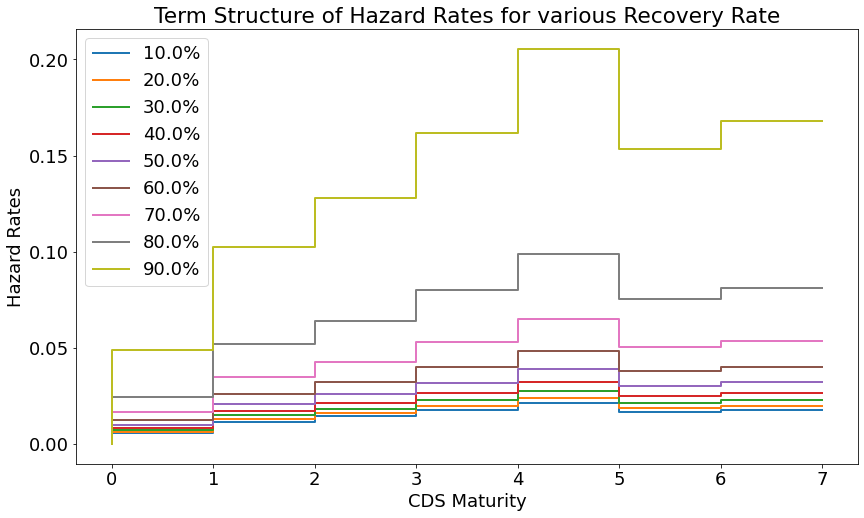

```python
hz = pd.DataFrame()

for i in arange(0.1, 1, 0.1):
    hz[i] = get_survival_probability(df.Maturity,df.Df,df.WFC,i)['Hazard']
    plt.step(hz.index, hz[i], label =f'{i*100:0.4}%')

plt.title('Term Structure of Hazard Rates for various Recovery Rate')
plt.xlabel('CDS Maturity')
plt.ylabel('Hazard Rates')
plt.legend();
```

## CCMO Observation

Let's plot the survival probability of CCMO and study its readings.

| Maturity | CCMO |
| --- | --- |
| 1Y | 751 |
| 2Y | 1164 |
| 3Y | 1874 |
| 4Y | 3015 |
| 5Y | 4156 |
| 6Y | 5119 |
| 7Y | 6083 |

```python
CCMO = get_survival_probability(df.Maturity,df.Df,df.CCMO,0.10,plot_prob=True)
```

[interactive chart not shown]

## Pricing with QuantLib Library

Given the maturity and market quoted spreads, we'll now derive the hazard rates and survival probability using QuantLib-Python and compare the result with the one derived above.

For this exercise, we use the Trans-European Automated Real-time Gross settlement Express Transfer (TARGET) calendar.

Further, we will compute cash values for Default Leg and Premium Leg in order to evaluate likely P&Ls from a credit swap.

| Maturity | Spread | Z(0; T) |
| --- | --- | --- |
| 0Y | 0 | 1 |
| 1Y | 50 | 0.97 |
| 2Y | 77 | 0.94 |
| 3Y | 94 | 0.92 |
| 4Y | 109.5 | 0.89 |
| 5Y | 125 | 0.86 |

```python
from QuantLib import *
```

```python
maturity = np.arange(6)
discountfactor = [1, 0.97, 0.94, 0.92, 0.89, 0.86]  # updated DF to 1 at 0Y
cds_spread = [0, 50, 77, 94, 109.5, 125]  # assume reasonable spreads from CDS Analytics I - HSBC bank
recovery = 0.40
```

```python
sp = get_survival_probability(maturity, discountfactor, cds_spread, recovery)
sp
```

[output not shown]

```python
# set up
calendar = TARGET()

todaysDate = Date(14, December, 2020)
Settings.instance().evaluationDate = todaysDate

risk_free_rate = YieldTermStructureHandle(FlatForward(todaysDate, 0.0, Actual365Fixed()))
```

### Hazard Rates

```python
# CDS parameters
recovery_rate = 0.4
quoted_spreads = [0.005, 0.0077, 0.0094, 0.01095, 0.0125]
tenors = [Period(1, Years),
          Period(2, Years),
          Period(3, Years),
          Period(4, Years),
          Period(5, Years)]
maturities = [calendar.adjust(todaysDate + x, Following) for x in tenors]

instruments = [
    SpreadCdsHelper(
        QuoteHandle(SimpleQuote(s)),
        tenor,
        0,
        calendar,
        Annual,
        Following,
        DateGeneration.TwentiethIMM,
        Actual365Fixed(),
        recovery_rate,
        risk_free_rate,
    )
    for s, tenor in zip(quoted_spreads, tenors)
]

# calculate hazard rate
hazard_curve = PiecewiseFlatHazardRate(todaysDate, instruments, Actual365Fixed())
print("---"*10)
print("Calibrated hazard rate values: ")
print("---"*10)
for x in hazard_curve.nodes():
    print("hazard rate on %s is %.7f" % x)

survival_probability = list(sp['Survival'])[1:]
temp = list(zip(maturities, survival_probability))

# calculate survival probability
print("---"*10)
print("Survival probability values: ")
print("---"*10)
counter = 1
for each in temp:
    print(f"{counter}Y probability QuantLib:{hazard_curve.survivalProbability(each[0]):.6}, \n\tcomputed by us {each[1]:.6}")
    counter = counter + 1
```

[output not shown]

### Reprice Instruments

```python
# reprice instruments
nominal = 1000000.0  # Notional Principal
probability = DefaultProbabilityTermStructureHandle(hazard_curve)

# create a cds for every maturity:
all_cds = []
for maturity, s in zip(maturities, quoted_spreads):
    schedule = Schedule(
        todaysDate,
        maturity,
        Period(Annual),
        calendar,
        Following,
        Unadjusted,
        DateGeneration.TwentiethIMM,
        False,
    )
    cds = CreditDefaultSwap(Protection.Seller, nominal, s, schedule, Following, Actual365Fixed())
    engine = MidPointCdsEngine(probability, recovery_rate, risk_free_rate)
    cds.setPricingEngine(engine)  # Computation of cashflows, PL and DL occurs here. Formulae below.
    all_cds.append(cds)

print("---"*20)
print("Repricing of quoted CDS spreads employed for calibration: ")
print("---"*20)
for cds, tenor in zip(all_cds, tenors):
    print(f"{tenor} Fair spread : {cds.fairSpread():.6}")
    print(f"   NPV         : {cds.NPV():.2}")
    print(f"   default leg : {cds.defaultLegNPV():.6}") # Default Leg x Notional Principal
    print(f"   coupon leg  : {cds.couponLegNPV():.6}")  # Premium Leg x Notional Principal
    print("")
```

[output not shown]

**SCENARIO**

We have purchased a 5Y CDS at 125 bps, so we are the PAYER of this fixed premium (coupon).

Market information came in about a potential trouble with the company's refinancing, and survival probabilities decreased. The value of default leg appreciated say to 200,000.

In dollar terms, PV-ed, we have committed to pay 60,211.2 only. Therefore, our scenario P&L is as follows:

$$ \displaystyle{ 200,000 - 60,211.2 \,=\, 139,788.8 } $$

The fair quote of the spread $S_N$ is such that the expected present value of the payments made by buyer and seller are equal **under a risk-neutral expectation**, i.e.

$$ PL_N = DL_N $$

**REMINDER CONTENT** from CDS Analytics - I

Premium legs are computed by multiplying with the corresponding discount factors and probability of survival at each payment dates (time points).

$$ \displaystyle{ PL_N = S_N \sum_{n=1}^N \, D(0,T_n) \, P(T_n) \, (\Delta t_n) } $$

where, $\Delta t_n$ is the year fraction corresponding to $T_{n-1} - T_n$ and $P(T_n)$ is the survival probability up to time $T_n$. This accounts for the expected present value of payments made from the buyer **A** to the seller **B**.

Default legs are conditional on the occurrence of default event. The exepcted present value of this payment depends on the recovery rate $R$ in the event of default. The loss payment on default is then equal to $(1-R)$ for every $ \$1 $ of notional principal. Thus, the expected present value of loss payments is given as

$$ \displaystyle{ DL_N = (1-R) \sum_{n=1}^N \, D(0,T_n) \, \left( P(T_{n-1}) - P(T_n) \right) } $$

The probability is given by the probability of surviving until period $n-1$ and then defaulting in periond $n$.

# References

- CDS Historical Data http://www.worldgovernmentbonds.com/cds-historical-data/ (careful of adverts)
- ESRB Risk Dashboard / Macro Risk https://sdw.ecb.europa.eu/reports.do?node=1000003315 (2.8 Sovereign debt CDS premia plotted)
- QuantLib-Python Documentation https://quantlib-python-docs.readthedocs.io/en/latest/index.html and QuantLib-SWIG https://github.com/lballabio
- Cufflinks Documentation https://github.com/santosjorge/cufflinks and https://plotly.com/python/cufflinks/